# Modelagem - MD

Jonatha Azevedo, Leonardo Filgueira, George Amarante, Michelle Jerônimo e Rafael Rangel

[figure not shown]

A proposta dessa modelagem é aplicar conhecimentos e técnicas em modelos lineares obtidos no curso. A modelagem será feita com um banco de dados que contém informações, entre 2010 à 2016, sobre os municípios do estado de São paulo. Após a modelagem, tentaremos criar métricas de redução de óbtos nas estradas do estado.

A modelagem será feita em duas partes:

- Análise de cluster (iremos agrupar os municípios)
- Regressão linear múltipla e tratamento dos resíduos

#### Análise de cluster

No banco de dados, não temos nenhuma variável que seja contextualizada para nosso problema, ou seja, não temos variáveis que remetem a óbtos, acidentes em rodovias, boletins de ocorrência e etc. a ideia da clusterização é nos ajudar a criar uma variável proxy que, de alguma forma, nos indique uma medida de acidentes em estradas.

##### Metodologia utilizada na abordagem

Como esse é um relatório, não explicitaremos a metodologia. Porém, para mais detalhes, há o trabalho em **PDF**.

```r
#carregando pacotes necessaios
require(corrplot)
require(normtest)
require(dplyr)
require(lmtest)
set.seed(6)

city_dataset<-read.csv2('city_dataset.csv')
city_dataset <- na.omit(city_dataset)
names(city_dataset)[1] = "cidade"
head(city_dataset)
```

```
##       cidade  ano       pib mat1517 veiculos motos populacao pop1519
## 1 Adamantina 2010 639090.51   94.96    19331  4556     33794    2673
## 2 Adamantina 2011 683689.22   91.96    20613  4987     33811    2573
## 3 Adamantina 2012 743683.94   89.34    21879  5389     33828    2477
## 4 Adamantina 2013 815579.34   93.64    22969  5608     33845    2382
## 5 Adamantina 2014 883055.34   96.98    23966  5845     33862    2289
## 8     Adolfo 2010  61059.15   73.42     1390   273      3558     268
##   pop2024 pop2529 pop60p    ibge jovem   pjovem   pmotos      pmat rodovia
## 1    2760    2492  17.56 3500105  7925 23.45091 23.56836 0.2809966      23
## 2    2734    2538  17.93 3500105  7845 23.20251 24.19347 0.2719825      23
## 3    2711    2583  18.29 3500105  7771 22.97209 24.63092 0.2641007      23
## 4    2687    2628  18.67 3500105  7697 22.74191 24.41552 0.2766731      23
## 5    2662    2670  19.04 3500105  7621 22.50605 24.38872 0.2863977      23
## 8     288     260  15.88 3500204   816 22.93423 19.64029 2.0635188       4
```

Algumas variáveis, como os grupos de jovens, foram transformadas. Além disso, criamos a densidade de veículos e o PIB *percapito* para cada município.

```r
pibpercapita <-city_dataset$pib/city_dataset$populacao
dens_vei     <-city_dataset$veiculos/city_dataset$rodovia
pop1519p     <-city_dataset$pop1519/city_dataset$populacao
pop2024p     <-city_dataset$pop2024/city_dataset$populacao
pop2529p     <-city_dataset$pop2529/city_dataset$populacao


base<-data.frame(cbind(pibpercapita,pop1519p,pop2024p,pop2529p,city_dataset$pjovem,city_dataset$pop60p,city_dataset$pmotos,city_dataset$pmat,dens_vei))
```

Depois de incorporar as transformações no bando de dados, podemos fazer a clusterização. Chegamos a uma inferência subjetiva de que teríamos mais chances de ter um óbto em um acidente de trânsito envolvendo motos e jovens. Essa é uma informação útil para o agrupamento.

Usaremos um método não hierárquico, o algoritmo de k-means, para a clusterização. Os métodos de agrupamentos se baseam em distâncias.

Basicamente, o modelo de Kmeans consiste em fazer uma escolha inicial dos k elementos que formam as sementes iniciais. Esta escolha pode ser feita da seguinte forma:

- Selecionado as k primeiras observações;
- Selecionando k observações aleatorioamente; e
- Escolhendo k observações de modo que seus valores sejam bastente diferentes.

Escolhida as sementes iniciais, é calculada a distância de cada elemento em relação às sementes, agrupando o elemento ao grupo que possuir a menor distância e recalculando o centróide do mesmo. O procedimento, naturalmente, é repetido até que todos os elementos façam parte de um dos clusters.

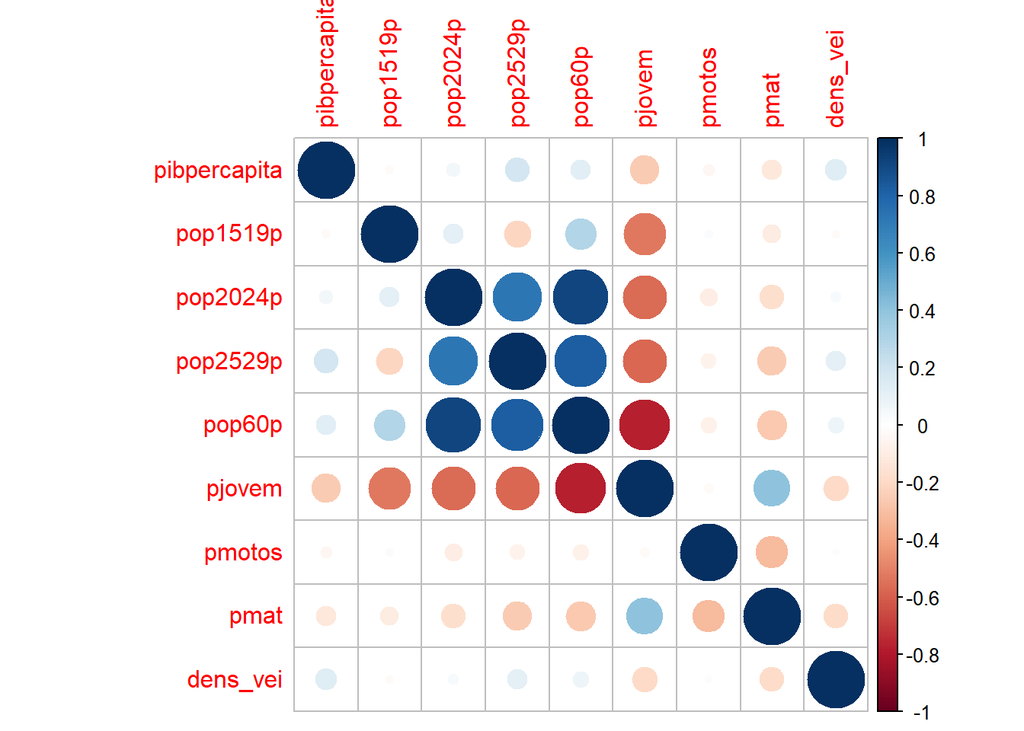

```r
names(base)[c(5:8)]<-c('pop60p','pjovem','pmotos','pmat')
omega<-cor(base,use = 'complete.obs')

corrplot(omega)
```

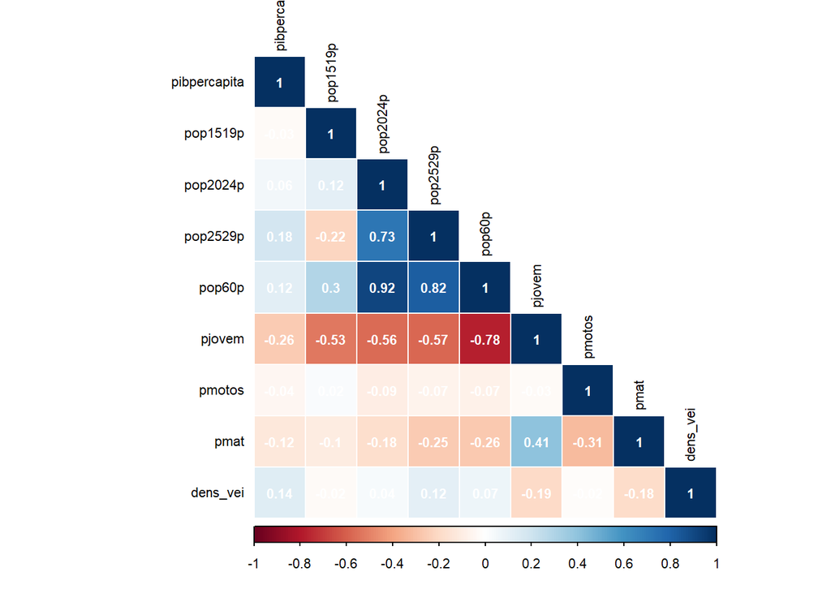

```r
corrplot(omega, method = "color", cl.pos = "b", type = "lower", addgrid.col = "white",
         addCoef.col = "white", tl.col = "black", tl.cex = 0.7, number.cex = 0.7, cl.cex = 0.7)
```

```r
  base = cbind(base,cidade =city_dataset$cidade,ano = city_dataset$ano)

base<-data.frame(cbind(pibpercapita,pop1519p,pop2024p,pop2529p,city_dataset$pjovem,city_dataset$pop60p, city_dataset$pmotos,city_dataset$pmat,dens_vei))
names(base)[c(5:8)]<-c('pop60p','pjovem','pmotos','pmat')
```

Criando os clusters com a função:

```r
kmeans_out<-kmeans(na.omit(base[,c('pjovem','pmotos','pop60p')]),centers = 6)
kmeans_out$size
```

```
## [1] 416 578 529 572 326 629
```

Introduzindo os grupos definidos anteriormente no banco de dados:

```r
membros <- kmeans_out$cluster
base<-base[rowSums(is.na(base[,c('pjovem','pmotos','pmat')]))==0,]
city_dataset_cluster <- cbind(base,grupos = membros)
head(city_dataset_cluster)
```

```
##   pibpercapita   pop1519p   pop2024p   pop2529p   pop60p pjovem   pmotos
## 1     18.91136 0.07909688 0.08167130 0.07374090 23.45091  17.56 23.56836
## 2     20.22091 0.07609949 0.08086126 0.07506433 23.20251  17.93 24.19347
## 3     21.98427 0.07322337 0.08014071 0.07635686 22.97209  18.29 24.63092
## 4     24.09748 0.07037967 0.07939134 0.07764810 22.74191  18.67 24.41552
## 5     26.07806 0.06759790 0.07861319 0.07884945 22.50605  19.04 24.38872
## 6     17.16109 0.07532322 0.08094435 0.07307476 22.93423  15.88 19.64029
##        pmat  dens_vei grupos
## 1 0.2809966  840.4783      4
## 2 0.2719825  896.2174      4
## 3 0.2641007  951.2609      4
## 4 0.2766731  998.6522      4
## 5 0.2863977 1042.0000      4
## 6 2.0635188  347.5000      6
```

A *proxy* será uma média ponderada entre as variáveis que usamos para a criação dos centróides, ou seja,

$$k_{proxy} = peso_{motos}pmotos + peso_{jovens}pjovens + peso_{pop60p}pop60p$$

onde $pmotos$, $pjovens$ e $pop60p$ são, respectivamente, a proporção de motos nos municípios, a proporção de jovens e a número de pessoas com mais de 60 anos na população.

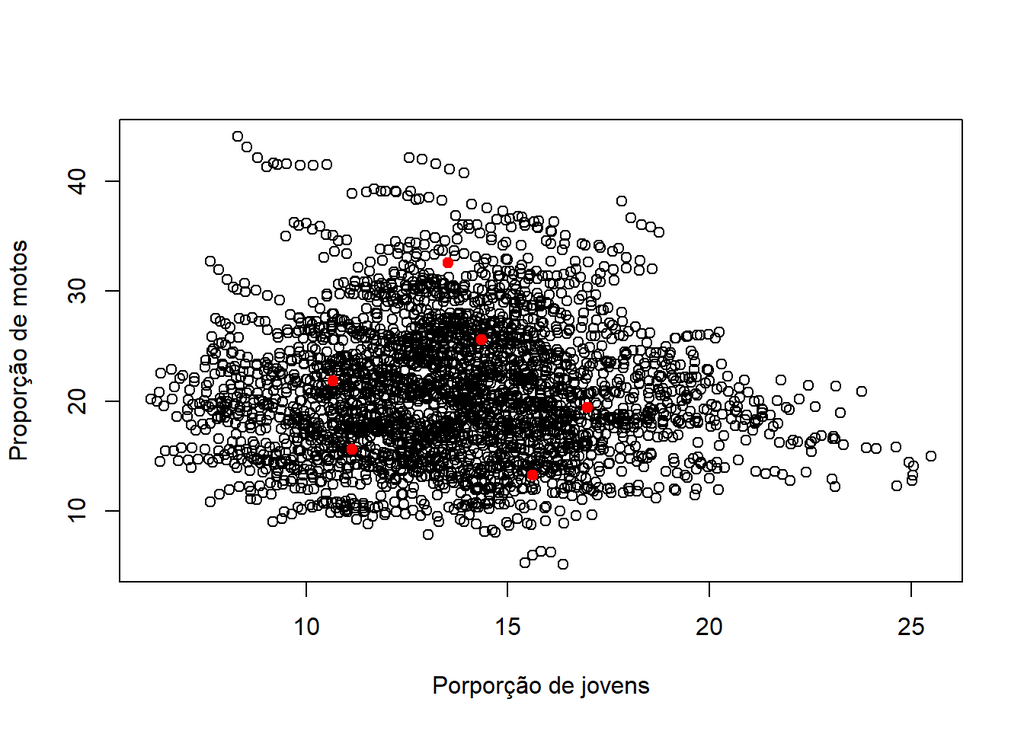

```r
ind_acidente<-rowSums(kmeans_out$centers)
city_dataset_cluster<-cbind(city_dataset_cluster,NA)
names(city_dataset_cluster)[dim(city_dataset_cluster)[2]]<-'ind_acidente'

for(i in 1:10){
  city_dataset_cluster[city_dataset_cluster$membros==i,'ind_acidente']<-ind_acidente[i]
}
plot(city_dataset_cluster$pjovem,city_dataset_cluster$pmotos,xlab="Porporção de jovens", ylab="Proporção de motos")
points(kmeans_out$centers,pch=19,col=2)
```

Agora, de fato, criremos os pesos e a variável proxy *“proxy_id_acidentes”*.

```r
pesos<-kmeans_out$centers/ind_acidente;pesos
```

```
##      pjovem    pmotos    pop60p
## 1 0.2929620 0.2484566 0.4585814
## 2 0.2078769 0.2914755 0.5006476
## 3 0.1789975 0.3668017 0.4542008
## 4 0.2224397 0.3962330 0.3813272
## 5 0.1905615 0.4594027 0.3500358
## 6 0.2842194 0.3257465 0.3900341
```

```r
aux = as.data.frame(pesos)

proxy_ind_acidente = rep(0,times = nrow(city_dataset_cluster))
dataset_final <- cbind(city_dataset_cluster,proxy_ind_acidente = proxy_ind_acidente)

for( i in 1:nrow(city_dataset_cluster)){
  if(city_dataset_cluster$grupo[i]  == 1){
    dataset_final$proxy_ind_acidente[i] = aux$pmotos[1]*dataset_final$pmotos[i] + aux$pjovem[1]*dataset_final$pjovem[i] + aux$pop60p[1]*dataset_final$pop60p[i]
  }else if(city_dataset_cluster$grupo[i]  == 2){
    dataset_final$proxy_ind_acidente[i] = aux$pmotos[2]*dataset_final$pmotos[i] + aux$pjovem[2]*dataset_final$pjovem[i] + aux$pop60p[2]*dataset_final$pop60p[i]
  }else if(city_dataset_cluster$grupo[i]  == 3){
    dataset_final$proxy_ind_acidente[i] = aux$pmotos[3]*dataset_final$pmotos[i] + aux$pjovem[3]*dataset_final$pjovem[i] + aux$pop60p[3]*dataset_final$pop60p[i]
  }else{
    dataset_final$proxy_ind_acidente[i] = aux$pmotos[4]*dataset_final$pmotos[i] + aux$pjovem[4]*dataset_final$pjovem[i] + aux$pop60p[4]*dataset_final$pop60p[i]
  }
}
```

Em estatística, uma *proxy* (ou variável proxy) é uma variável que não é diretamente relevante por si só, mas atua no lugar de uma variável não observável ou não mensurável para descobrir um resultado provável.

Para que a variável em questão seja uma boa proxy, é preciso que haja uma forte correlação, não necessariamente linear, com a variável que se busca analisar. Essa correlação pode ser tanto positiva quanto negativa.

Com a proxy criada, vamos criar um modelo linear pra verificar quais variáveis explicam a nossa proxy.

```r
modelo <-  lm(formula = proxy_ind_acidente~pibpercapita+pmat+dens_vei,data = dataset_final)
summary(modelo)
```

```
##
## Call:
## lm(formula = proxy_ind_acidente ~ pibpercapita + pmat + dens_vei,
##     data = dataset_final)
##
## Residuals:
##     Min      1Q  Median      3Q     Max
## -4.5891 -1.4350 -0.3024  1.0385  8.1373
##
## Coefficients:
##                Estimate Std. Error t value Pr(>|t|)
## (Intercept)   2.230e+01  6.817e-02 327.125  < 2e-16 ***
## pibpercapita -7.784e-03  1.977e-03  -3.937 8.42e-05 ***
## pmat         -6.926e-01  3.478e-02 -19.911  < 2e-16 ***
## dens_vei     -6.357e-05  1.376e-05  -4.620 3.99e-06 ***
## ---
## Signif. codes:  0 '***' 0.001 '**' 0.01 '*' 0.05 '.' 0.1 ' ' 1
##
## Residual standard error: 1.952 on 3046 degrees of freedom
## Multiple R-squared:  0.1168, Adjusted R-squared:  0.1159
## F-statistic: 134.3 on 3 and 3046 DF,  p-value: < 2.2e-16
```

Temos que as variáveis PIB percapto, quantidade de jovens matriculados no ensino médio e a densidade de veículos são estatisticamente significantes para a proxy. Tirando, claro, as variáveis que foram usadas para definir o processo gerador.

#### Qualidade do ajuste

Temos que olhar os resíduos para verificar se nosso modelo é adequado, ou pelo menos, razoável.

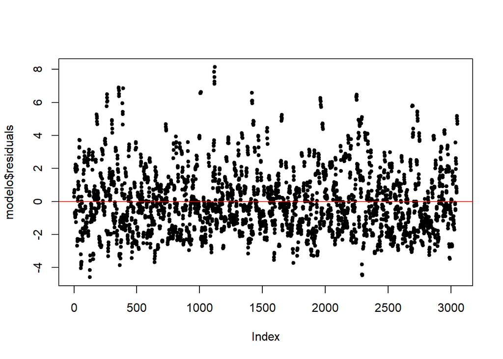

```r
plot(modelo$residuals,pch=20)
abline(h=0,col=2)
```

Verificando normalidade dos resíduos com o `shapiro.test()`, temos :

```r
shapiro.test(modelo$residuals)
```

```
##
##  Shapiro-Wilk normality test
##
## data:  modelo$residuals
## W = 0.95961, p-value < 2.2e-16
```

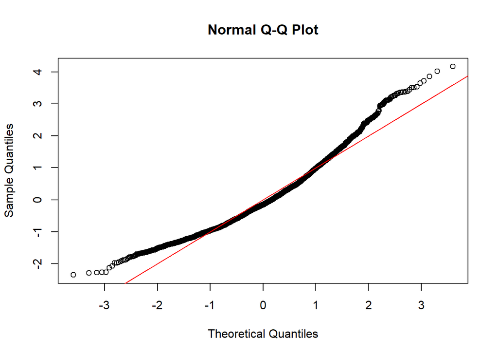

```r
normalizando = (modelo$residuals - mean(modelo$residuals))/sd(modelo$residuals)
qqnorm(normalizando)
abline(c(0,1),col=2)
```

Ou seja, pelo p-valor < 2.2e-16, rejeitamos a hipótese de que os resíduos seguem uma distribuição normal. Vejamos também o histograma dos resíduos, com a curva da distribuição normal sobre o gráfico:

Histograma dos resíduos e curva da distribuição normal sobre o histograma:

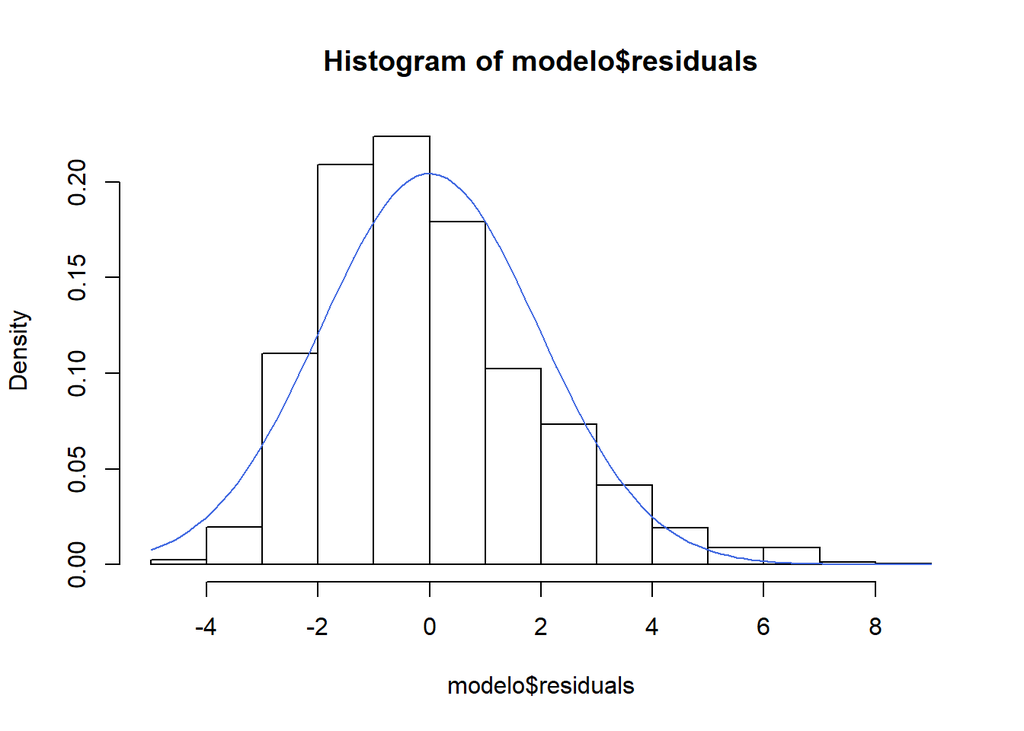

```r
hist(modelo$residuals, prob = T)
curve(dnorm(x, mean(modelo$residuals), sd(modelo$residuals)), add = T, col = "royalblue")
```

Verificando homocedasticidade dos resíduos com o teste de Breusch-Pagan:

```r
bptest(modelo)
```

```
##
##  studentized Breusch-Pagan test
##
## data:  modelo
## BP = 5.5451, df = 3, p-value = 0.136
```

O gráfico confirma o que concluímos com o teste de Shapiro. Por outro lado, pelo teste de Breusch-Pagan, que testa a hipótese nula de que os resíduos do modelo são homocedásticos, retorna um resultado que pode ser satisfatório. Ainda assim precisamos melhorar isso. A função `boxcox` nos ajuda a obter uma transformação dos dados, tranformação essa que pode nos ajudar a obter algumas propriedades desejadas nos resíduos.

```r
require(MASS)
a = MASS::boxcox(modelo)
```

[figure not shown]

```r
lambda <- a$x[which.max(a$y)];lambda
```

```
## [1] -2
```

Iremos usar o varlor de $\lambda$ que maximiza y com a fórmula proposta por Box e Cox, da seguinte forma:

$$y(\lambda) = \left\{\begin{matrix}
\frac{(Y + \lambda_{1})^{\lambda_{1}}-1}{\lambda_{1}},& \mbox{se} & \lambda \neq 0;\\
log(y + \lambda_{2}),& \mbox{se} & \lambda = 0
\end{matrix}\right.$$

Com isso, temos:

```r
dataset_t = as.data.frame(matrix(rep(0,times = length(dataset_final)),nrow = nrow(dataset_final),ncol=ncol(dataset_final)))
names(dataset_t) = names(dataset_final)
for(i in 1:nrow(dataset_final)){
  for(j in 1:ncol(dataset_final)){
    aux = (((dataset_final[i,j] +lambda)^lambda)-1)/lambda
    dataset_t[i,j] = aux
  }
}

# dataset_t = log(dataset_final)
head(dataset_t)
```

```
##   pibpercapita  pop1519p  pop2024p  pop2529p    pop60p    pjovem    pmotos
## 1    0.4982517 0.3644938 0.3641299 0.3652463 0.4989134 0.4979349 0.4989252
## 2    0.4984940 0.3649157 0.3642446 0.3650610 0.4988878 0.4980297 0.4989849
## 3    0.4987480 0.3653187 0.3643464 0.3648796 0.4988632 0.4981158 0.4990237
## 4    0.4989760 0.3657154 0.3644523 0.3646980 0.4988378 0.4982007 0.4990049
## 5    0.4991376 0.3661017 0.3645620 0.3645287 0.4988109 0.4982780 0.4990025
## 6    0.4978247 0.3650247 0.3642328 0.3653395 0.4988591 0.4974047 0.4983932
##           pmat  dens_vei  grupos ind_acidente proxy_ind_acidente
## 1    0.3307937 0.4999993 0.37500           NA          0.4987731
## 2    0.3325544 0.4999994 0.37500           NA          0.4988012
## 3    0.3340715 0.4999994 0.37500           NA          0.4988204
## 4    0.3316417 0.4999995 0.37500           NA          0.4988102
## 5    0.3297254 0.4999995 0.37500           NA          0.4988080
## 6 -123.4267359 0.4999958 0.46875           NA          0.4984670
```

Logo, aplicamos novamente a regressão linear múltipla:

```r
modelo2 <-  lm(formula = proxy_ind_acidente~pibpercapita+pmat+dens_vei,data = dataset_t)
summary(modelo2)
```

```
##
## Call:
## lm(formula = proxy_ind_acidente ~ pibpercapita + pmat + dens_vei,
##     data = dataset_t)
##
## Residuals:
##        Min         1Q     Median         3Q        Max
## -8.008e-04 -1.957e-04 -6.040e-06  1.921e-04  7.068e-04
##
## Coefficients:
##                Estimate Std. Error t value Pr(>|t|)
## (Intercept)   4.576e-01  9.889e-03  46.271  < 2e-16 ***
## pibpercapita -5.166e-03  1.215e-03  -4.252 2.18e-05 ***
## pmat         -1.817e-10  8.735e-10  -0.208    0.835
## dens_vei      8.732e-02  2.008e-02   4.348 1.42e-05 ***
## ---
## Signif. codes:  0 '***' 0.001 '**' 0.01 '*' 0.05 '.' 0.1 ' ' 1
##
## Residual standard error: 0.0002676 on 3046 degrees of freedom
## Multiple R-squared:  0.009524,   Adjusted R-squared:  0.008548
## F-statistic: 9.763 on 3 and 3046 DF,  p-value: 2.08e-06
```

Como a variável *pmat* não é significativa:

```r
modelo2 <-  lm(formula = proxy_ind_acidente~pibpercapita+dens_vei,data = dataset_t)
summary(modelo2)
```

```
##
## Call:
## lm(formula = proxy_ind_acidente ~ pibpercapita + dens_vei, data = dataset_t)
##
## Residuals:
##        Min         1Q     Median         3Q        Max
## -8.007e-04 -1.957e-04 -6.040e-06  1.932e-04  7.067e-04
##
## Coefficients:
##               Estimate Std. Error t value Pr(>|t|)
## (Intercept)   0.457529   0.009886  46.279  < 2e-16 ***
## pibpercapita -0.005190   0.001210  -4.291 1.84e-05 ***
## dens_vei      0.087391   0.020075   4.353 1.39e-05 ***
## ---
## Signif. codes:  0 '***' 0.001 '**' 0.01 '*' 0.05 '.' 0.1 ' ' 1
##
## Residual standard error: 0.0002676 on 3047 degrees of freedom
## Multiple R-squared:  0.00951,    Adjusted R-squared:  0.008859
## F-statistic: 14.63 on 2 and 3047 DF,  p-value: 4.763e-07
```

Plotando os resíduos com os dados transformados, temos:

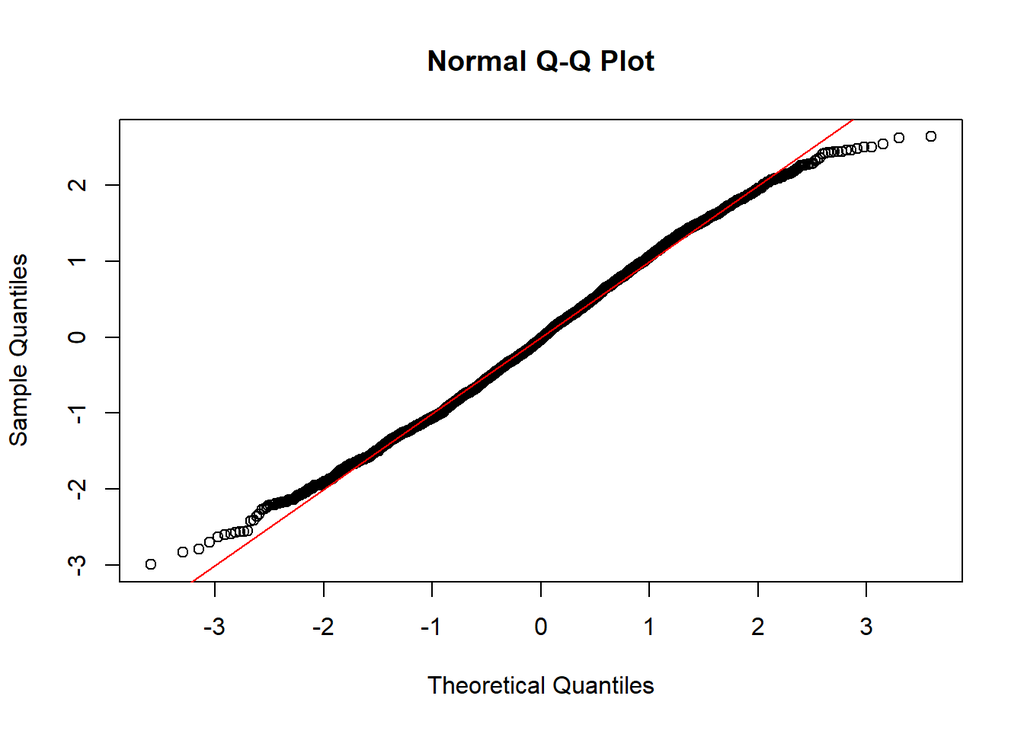

```r
normalizando2 = (modelo2$residuals - mean(modelo2$residuals))/sd(modelo2$residuals)
qqnorm(normalizando2)
abline(c(0,1),col=2)
```

```r
shapiro.test(modelo2$residuals)
```

```
##
##  Shapiro-Wilk normality test
##
## data:  modelo2$residuals
## W = 0.9956, p-value = 7.552e-08
```

Visualizando a distribuição dos resíduos e plotando a densidade da distribuição normal:

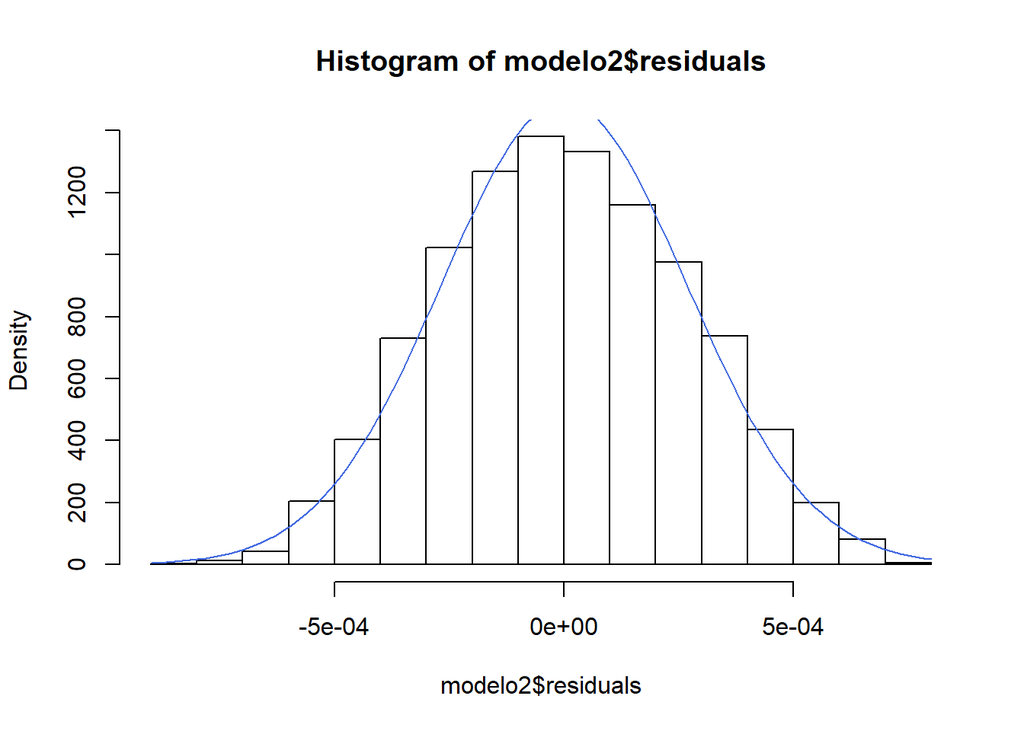

```r
hist(modelo2$residuals, prob = T)
curve(dnorm(x, mean(modelo2$residuals), sd(modelo2$residuals)), add = T, col = "royalblue")
```

Verificando homocedasticidade dos resíduos com o teste de Breusch-Pagan:

```r
bptest(modelo2)
```

```
##
##  studentized Breusch-Pagan test
##
## data:  modelo2
## BP = 11.034, df = 2, p-value = 0.004019
```

Rodando separadamente regressões lineares simples:

```r
aux1 <- lm(formula =proxy_ind_acidente ~ pibpercapita ,data = dataset_t )
summary(aux1)
```

```
##
## Call:
## lm(formula = proxy_ind_acidente ~ pibpercapita, data = dataset_t)
##
## Residuals:
##        Min         1Q     Median         3Q        Max
## -9.078e-04 -1.982e-04 -5.130e-06  1.942e-04  7.126e-04
##
## Coefficients:
##                Estimate Std. Error t value Pr(>|t|)
## (Intercept)   0.5004930  0.0005791   864.2  < 2e-16 ***
## pibpercapita -0.0037302  0.0011655    -3.2  0.00139 **
## ---
## Signif. codes:  0 '***' 0.001 '**' 0.01 '*' 0.05 '.' 0.1 ' ' 1
##
## Residual standard error: 0.0002684 on 3048 degrees of freedom
## Multiple R-squared:  0.003349,   Adjusted R-squared:  0.003022
## F-statistic: 10.24 on 1 and 3048 DF,  p-value: 0.001386
```

```r
aux2 <- lm(formula =proxy_ind_acidente ~ dens_vei ,data = dataset_t )
summary(aux2)
```

```
##
## Call:
## lm(formula = proxy_ind_acidente ~ dens_vei, data = dataset_t)
##
## Residuals:
##        Min         1Q     Median         3Q        Max
## -8.335e-04 -1.999e-04 -4.730e-06  1.916e-04  7.122e-04
##
## Coefficients:
##             Estimate Std. Error t value Pr(>|t|)
## (Intercept)  0.46689    0.00967  48.281  < 2e-16 ***
## dens_vei     0.06351    0.01934   3.283  0.00104 **
## ---
## Signif. codes:  0 '***' 0.001 '**' 0.01 '*' 0.05 '.' 0.1 ' ' 1
##
## Residual standard error: 0.0002683 on 3048 degrees of freedom
## Multiple R-squared:  0.003525,   Adjusted R-squared:  0.003198
## F-statistic: 10.78 on 1 and 3048 DF,  p-value: 0.001037
```

```r
aux3 <- lm(formula =proxy_ind_acidente ~ pmat ,data = dataset_t )
summary(aux3)
```

```
##
## Call:
## lm(formula = proxy_ind_acidente ~ pmat, data = dataset_t)
##
## Residuals:
##        Min         1Q     Median         3Q        Max
## -9.105e-04 -2.013e-04 -3.550e-06  1.954e-04  7.157e-04
##
## Coefficients:
##               Estimate Std. Error    t value Pr(>|t|)
## (Intercept)  4.986e-01  4.869e-06 102414.057   <2e-16 ***
## pmat        -5.036e-10  8.735e-10     -0.577    0.564
## ---
## Signif. codes:  0 '***' 0.001 '**' 0.01 '*' 0.05 '.' 0.1 ' ' 1
##
## Residual standard error: 0.0002688 on 3048 degrees of freedom
## Multiple R-squared:  0.000109,   Adjusted R-squared:  -0.000219
## F-statistic: 0.3324 on 1 and 3048 DF,  p-value: 0.5643
```

Verificando a transformação com log.

```r
dataset_t_log = log(dataset_final)
```

Logo, aplicamos novamente a regressão linear múltipla:

```r
modelo3 <-  lm(formula = proxy_ind_acidente~pibpercapita+pmat+dens_vei,data = dataset_t_log)
summary(modelo3)
```

```
##
## Call:
## lm(formula = proxy_ind_acidente ~ pibpercapita + pmat + dens_vei,
##     data = dataset_t_log)
##
## Residuals:
##      Min       1Q   Median       3Q      Max
## -0.29964 -0.06110 -0.00838  0.05152  0.33828
##
## Coefficients:
##               Estimate Std. Error t value Pr(>|t|)
## (Intercept)   3.176770   0.012597 252.189  < 2e-16 ***
## pibpercapita -0.027876   0.003157  -8.831  < 2e-16 ***
## pmat         -0.034322   0.001885 -18.207  < 2e-16 ***
## dens_vei     -0.010899   0.002080  -5.239 1.72e-07 ***
## ---
## Signif. codes:  0 '***' 0.001 '**' 0.01 '*' 0.05 '.' 0.1 ' ' 1
##
## Residual standard error: 0.0873 on 3046 degrees of freedom
## Multiple R-squared:  0.1397, Adjusted R-squared:  0.1389
## F-statistic: 164.9 on 3 and 3046 DF,  p-value: < 2.2e-16
```

$$Y = \beta_{0} -\beta_{1}x_{1} - \beta_{2}x_{2} - \beta_{3}x_{3} + e_{i}, \hspace{0.2cm} \mbox{para} \hspace{0.15cm} i = 1, \dots, n$$

onde, $e_i \sim N(0,\alpha^{2})$ , onde $e_i$ são i.i.d.

Plotando os resíduos com os dados transformados, temos

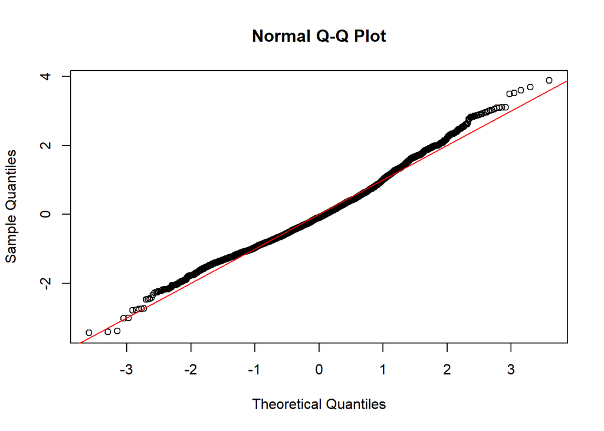

```r
normalizando3 = (modelo3$residuals - mean(modelo3$residuals))/sd(modelo3$residuals)
qqnorm(normalizando3)
abline(c(0,1),col=2)
```

Verificando normalidade desse novo modelo, temos

```r
shapiro.test(modelo3$residuals)
```

```
##
##  Shapiro-Wilk normality test
##
## data:  modelo3$residuals
## W = 0.98746, p-value = 8.809e-16
```

Visualizando a distribuição dos resíduos e plotando a densidade da distribuição normal:

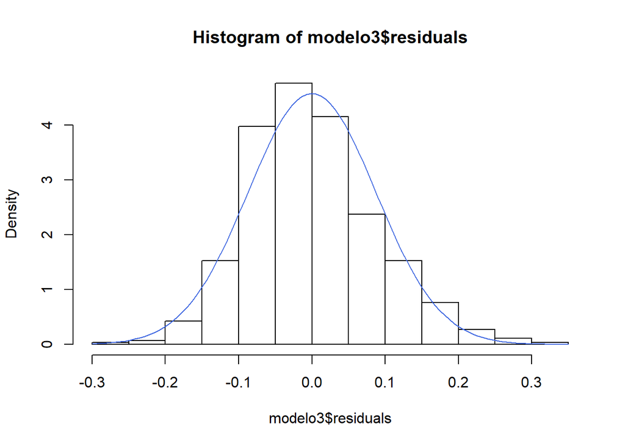

```r
hist(modelo3$residuals, prob = T)
curve(dnorm(x, mean(modelo3$residuals), sd(modelo3$residuals)), add = T, col = "royalblue")
```

Verificando homocedasticidade dos resíduos com o teste de Breusch-Pagan:

```r
bptest(modelo3)
```

```
##
##  studentized Breusch-Pagan test
##
## data:  modelo3
## BP = 113.31, df = 3, p-value < 2.2e-16
```

Ao fazer o boxplot da proxy transformada, podemos perceber que há alguns outliers:

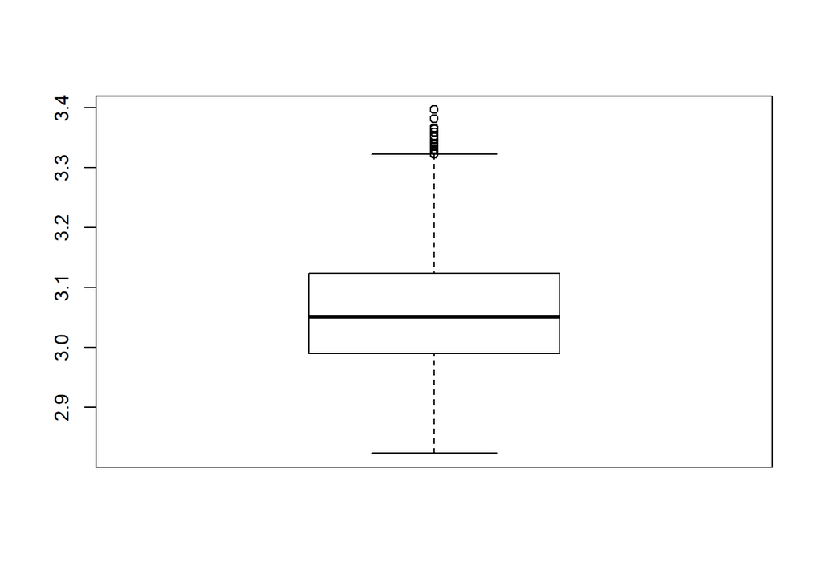

```r
boxplot(dataset_t_log$proxy_ind_acidente)
```

Iremos retirar estes outliers do conjunto de dados:

```r
obs <- boxplot(dataset_t_log$proxy_ind_acidente)
```

```r
out <- obs$out
dataset_t_log <- dataset_t_log %>% filter(!(proxy_ind_acidente %in% out))
```

Aplicamos mais uma vez a regressão linear múltipla:

```r
modelo4 <-  lm(formula = proxy_ind_acidente~pibpercapita+pmat+dens_vei,data = dataset_t_log)
summary(modelo4)
```

```
##
## Call:
## lm(formula = proxy_ind_acidente ~ pibpercapita + pmat + dens_vei,
##     data = dataset_t_log)
##
## Residuals:
##       Min        1Q    Median        3Q       Max
## -0.288191 -0.059809 -0.006385  0.051027  0.269805
##
## Coefficients:
##               Estimate Std. Error t value Pr(>|t|)
## (Intercept)   3.177545   0.012207 260.308  < 2e-16 ***
## pibpercapita -0.027102   0.003078  -8.804  < 2e-16 ***
## pmat         -0.033373   0.001826 -18.279  < 2e-16 ***
## dens_vei     -0.011694   0.002016  -5.802 7.23e-09 ***
## ---
## Signif. codes:  0 '***' 0.001 '**' 0.01 '*' 0.05 '.' 0.1 ' ' 1
##
## Residual standard error: 0.08431 on 3020 degrees of freedom
## Multiple R-squared:  0.136,  Adjusted R-squared:  0.1352
## F-statistic: 158.5 on 3 and 3020 DF,  p-value: < 2.2e-16
```

Plotando os resíduos com os dados transformados sem outliers, temos

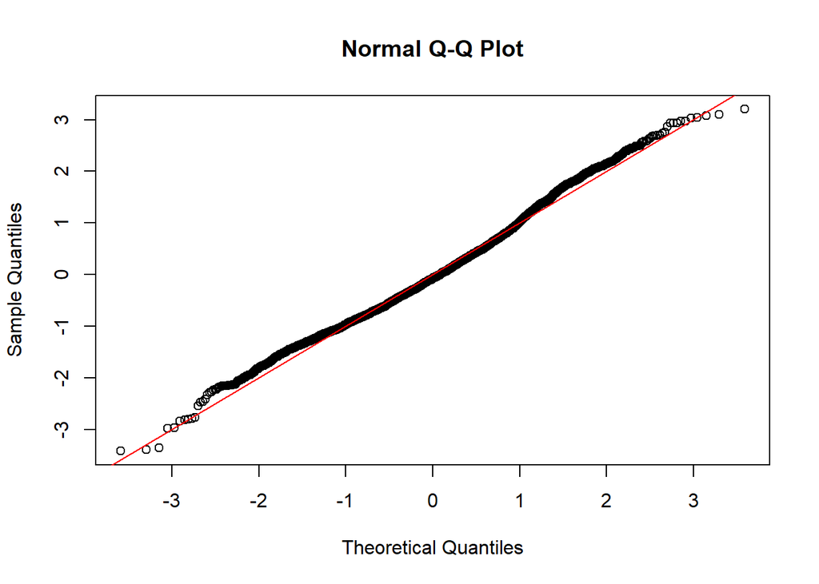

```r
normalizando4 = (modelo4$residuals - mean(modelo4$residuals))/sd(modelo4$residuals)
qqnorm(normalizando4)
abline(c(0,1),col=2)
```

Verificando normalidade desse novo modelo, temos:

```r
shapiro.test(modelo4$residuals)
```

```
##
##  Shapiro-Wilk normality test
##
## data:  modelo4$residuals
## W = 0.99096, p-value = 6.673e-13
```

Histograma dos resíduos e curva da distribuição normal sobre o histograma:

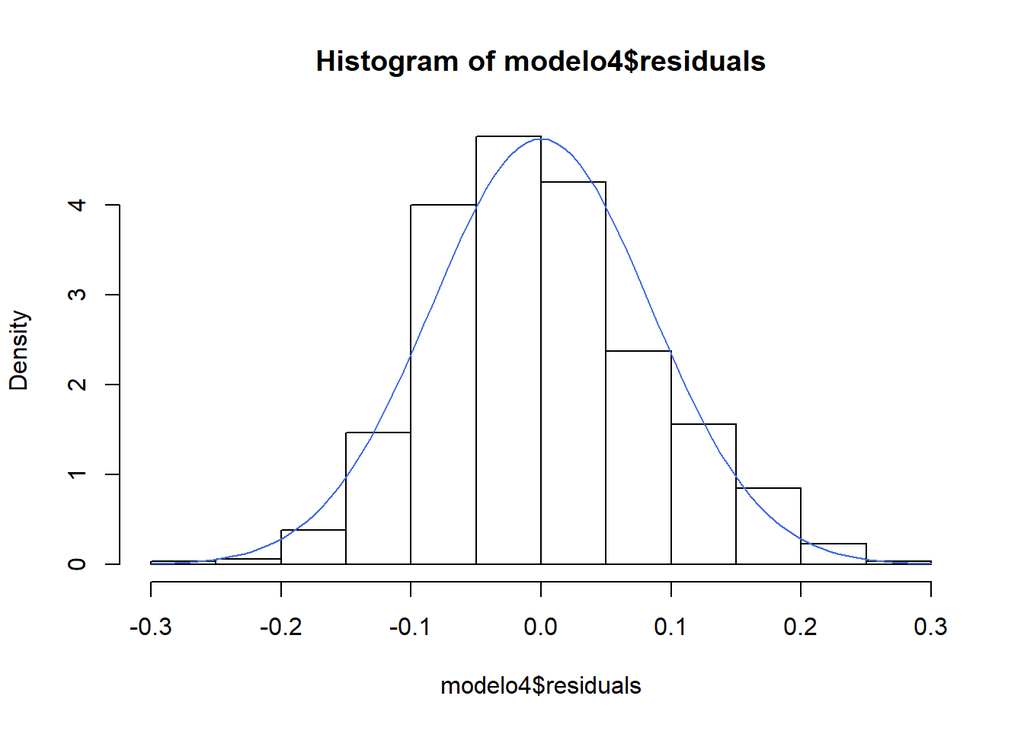

```r
hist(modelo4$residuals, prob = T)
curve(dnorm(x, mean(modelo4$residuals), sd(modelo4$residuals)), add = T, col = "royalblue")
```

Verificando homocedasticidade dos resíduos com o teste de Breusch-Pagan:

```r
bptest(modelo4)
```

```
##
##  studentized Breusch-Pagan test
##
## data:  modelo4
## BP = 100.48, df = 3, p-value < 2.2e-16
```

….

Gráficos de dispersões:

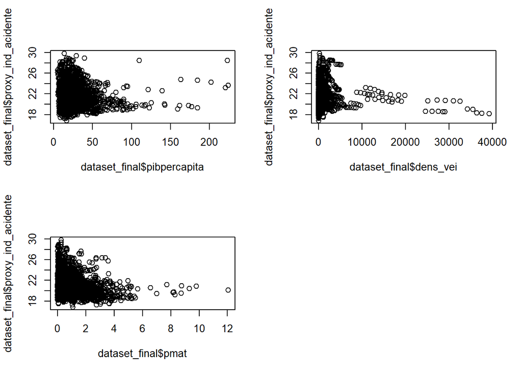

```r
old.par <- par(mfrow=c(2,2))
plot( dataset_final$proxy_ind_acidente~dataset_final$pibpercapita,cex=1.1)
plot( dataset_final$proxy_ind_acidente~dataset_final$dens_vei,cex=1.1)
plot( dataset_final$proxy_ind_acidente~dataset_final$pmat,cex=1.1)
par(old.par)
```

#### Conclusão

Ficou evidente que precisamos de uma amostra maior, dados de 2010 à 2016 não são suficientes para garantir com propriedade se a proxy criada é adequada para ser utilizada na medição de acidentes de transitos nas rodovias dos municípios de São Paulo. Tentamos transformar os dados que, em certo ponto, melhorou algumas propriedades.

Com poucos dados, para esse fim, temos um viés em relação aos resíduos. Com essa amostra temos uma probabilidade grande de cometer o erro do tipo I nos testes estatísticos que necessitam de normalidade dos resíduos.

Se não considerássemos os testes e olhassemos apenas para os gráficos (histograma, qqnorm e etc) poderíamos assumir um comportamento normal.

Verificamos que possuíamos *outliers*, cerca de 25, e que tirando eles poderíamos ter normalidade nos resíduos. O que também não aconteceu, mesmo usando testes mais *fracos* para essa propriedade.

Então, como proposta de melhora na modelagem, consideramos obter uma amostra maior. Pois isso pode interferir diretamente na clusterização, dividindo melhor os municípios e seus grupos. Gerando menos concentração. Consequentemente termos uma proxy melhor e poderemos ver uma relação mais clara e forte com as variáveis explicativas, como o pib percapito e a densidade de veículos, jpa que usamos as variáveis *proporção de motos*, *proporção de jovens* e *proporção de pessoas com mais de 60 anos* para o processo gerador.